# ExtraaLearn Project

### **Lets perform Bivariate and Multivariate analysis**

# Lets check how Status field is related with other categorical fields.

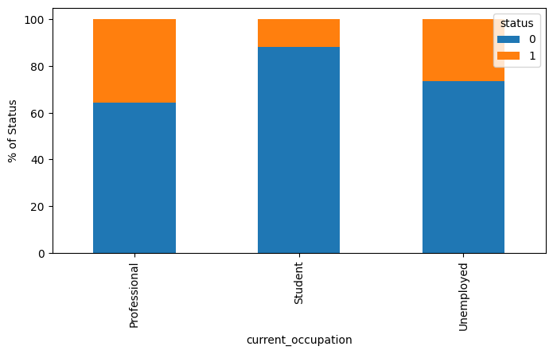

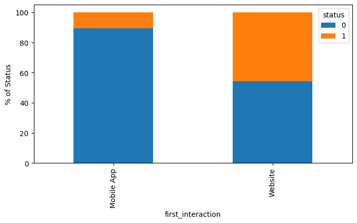

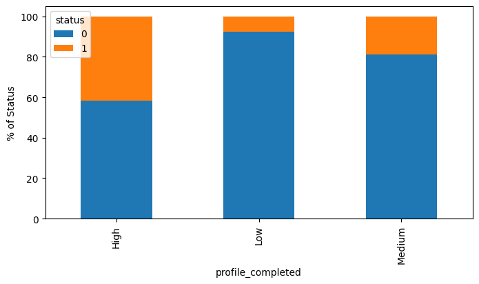

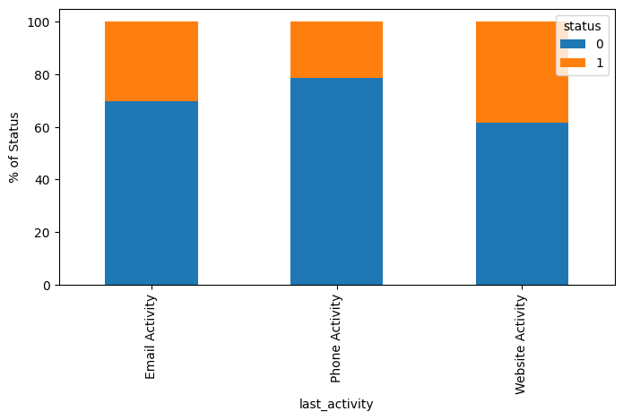

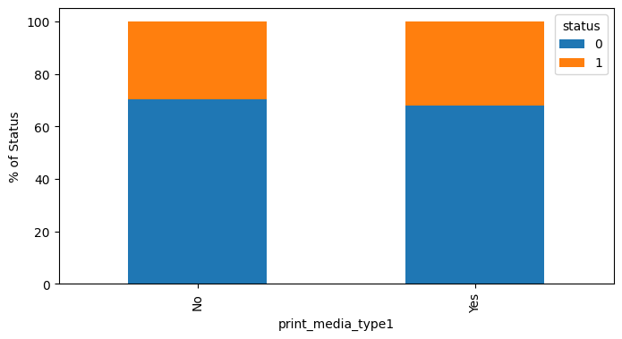

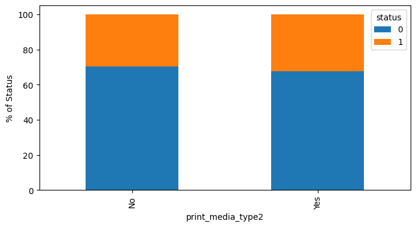

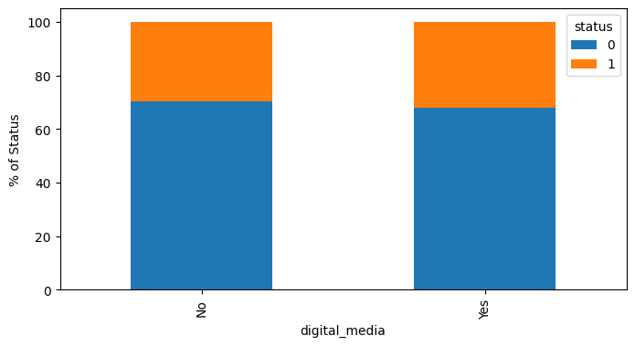

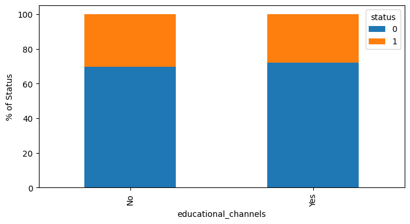

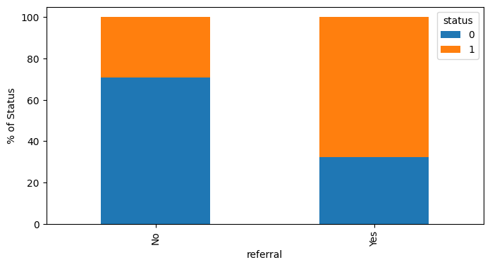

```python
for i in cat_cols:
    if i!='status':
        (pd.crosstab(df[i],df['status'],normalize='index')*100).plot(kind='bar',figsize=(8,4),stacked=True)
        plt.ylabel('% of Status')
```

# Observation

- Only ~10% - 15% of student were converted to paid member.
- Majority paid members are either professionals or unemployed.
- first_interaction indicates that the leads coming through website have more than 40% chances of converting to paid members.
- Mobile app has very less number of leads converted to paid customers. It indicates that more work need to be done on mobile app.
- Profile_completed indicates that if lead completed more that 75% of profile then there are more than 35% chance that it will become paid member. It also indicates that if lead has completed < 25% of profile then there are very low chances of it converting to lead.
- Phone activity as last_activity indicates that there is 80% chance that laead will not be converted to paid member. Other two activities as last_activity indicate that 60% - 70% chance the lead would not convert to paid member. It is still better than phone activity.
- There is more than 60% chance of lead converting to paid member if it has come through referral.

**Let's check the relationship between attrition and Numerical variables**

```python
# Mean of numerical variables grouped by status
df.groupby(['status'])[num_cols].mean()
```

| status | age | website_visits | time_spent_on_website | page_views_per_visit | status |
| --- | --- | --- | --- | --- | --- |
| 0 | 45.153014 | 3.578980 | 577.420711 | 3.025732 | 0.0 |
| 1 | 48.663762 | 3.538126 | 1068.397967 | 3.027050 | 1.0 |

```python
df.groupby(['status'])['status'].count()
```

```
status
0    3235
1    1377
Name: status, dtype: int64
```

## **Let's check the relationship between different numerical variables**

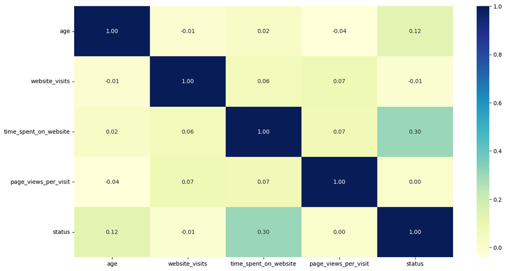

```python
# Plotting the correlation between numerical variables
plt.figure(figsize=(15,8))
sns.heatmap(df[num_cols].corr(),annot=True, fmt='0.2f', cmap='YlGnBu')
```

**Questions**

1. Leads will have different expectations from the outcome of the course and the current occupation may play a key role in getting them to participate in the program. Find out how current occupation affects lead status.
2. The company's first impression on the customer must have an impact. Do the first channels of interaction have an impact on the lead status?
3. The company uses multiple modes to interact with prospects. Which way of interaction works best?
4. The company gets leads from various channels such as print media, digital media, referrals, etc. Which of these channels have the highest lead conversion rate?
5. People browsing the website or mobile application are generally required to create a profile by sharing their personal data before they can access additional information.Does having more details about a prospect increase the chances of conversion?

## Data Preprocessing

- Missing value treatment (if needed)
- Feature engineering (if needed)
- Outlier detection and treatment (if needed)
- Preparing data for modeling
- Any other preprocessing steps (if needed)

**Observations**

- There are no missing values to be treated
- For decision Tree and Random forest model, no feature engineering is needed as they are not sensitive to variance of the data.

**Preparing data for model creation**

```python
# Creating dummy values for categorical column

df_new = pd.get_dummies(data=df,columns=cat_cols, drop_first=True)
print(df_new.head());
```

```
   age  website_visits  time_spent_on_website  page_views_per_visit  status  \
0   57               7                   1639                 1.861       1
1   56               2                     83                 0.320       0
2   52               3                    330                 0.074       0
3   53               4                    464                 2.057       1
4   23               4                    600                16.914       0

   current_occupation_Student  current_occupation_Unemployed  \
0                       False                           True
1                       False                          False
2                       False                          False
3                       False                           True
4                        True                          False

   first_interaction_Website  profile_completed_Low  profile_completed_Medium  \
```

[output cut: 26 more lines]

**Separating dependent and independent variables.**

```python
df_Y=df_new.status
df_X=df_new.drop(columns=['status'])
```

**Splitting data into 70:30 ratio for test and train.**

```python
X_train, X_test, y_train, y_test = train_test_split(df_X, df_Y, test_size = 0.3, random_state = 1, stratify = df_Y)
```

```python
# Creating metric function
def metrics_score(actual, predicted):
    print(classification_report(actual, predicted))

    cm = confusion_matrix(actual, predicted)
    plt.figure(figsize=(8,5))

    sns.heatmap(cm, annot=True,  fmt='.2f', xticklabels=['Not Converted', 'Converted'], yticklabels=['Not Converted', 'Converted'])
    plt.ylabel('Actual')
    plt.xlabel('Predicted')
    plt.show()
```

## Building a Decision Tree model

```python
dt = DecisionTreeClassifier(class_weight={0:0.70,1:0.30},random_state = 1)
dt.fit(X_train, y_train);
```

```python
y_train_pred_dt = dt.predict(X_train)
```

```
              precision    recall  f1-score   support

           0       1.00      1.00      1.00      2264
           1       1.00      1.00      1.00       964

    accuracy                           1.00      3228
   macro avg       1.00      1.00      1.00      3228
weighted avg       1.00      1.00      1.00      3228
```

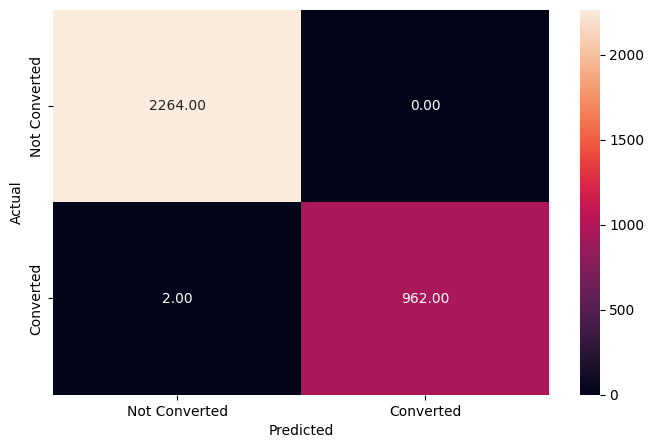

```python
metrics_score(y_train, y_train_pred_dt)
```

## **Observation**

- Decision Tree is giving almost **100% score for all metrics on the training dataset**.

```
              precision    recall  f1-score   support

           0       0.86      0.85      0.85       971
           1       0.65      0.68      0.67       413

    accuracy                           0.80      1384
   macro avg       0.76      0.76      0.76      1384
weighted avg       0.80      0.80      0.80      1384
```

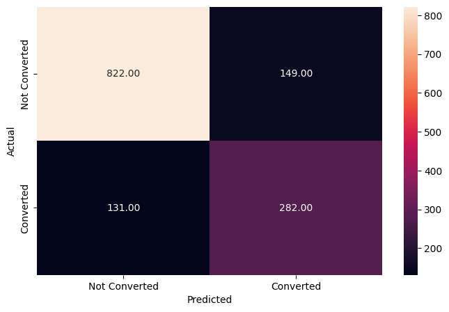

```python
# Checking performance of test dataset.

y_test_pred_dt = dt.predict(X_test)

metrics_score(y_test, y_test_pred_dt)
```

**Observations**:

- The Decision Tree works well on the training data but not so well on the test data as **the recall is 0.68 in comparison to 1 for the training dataset, i.e., the Decision Tree is overfitting the training data.**
- The precision on the test data suggests that there's **a 35% (1 - 0.65) chance that the model will predict that a lead is going to convert as paid customer even though he/she would not, and the company may waste their time and energy on these employees who are not at risk of attrition.**

### **Let's plot the feature importance and check the most important features.**

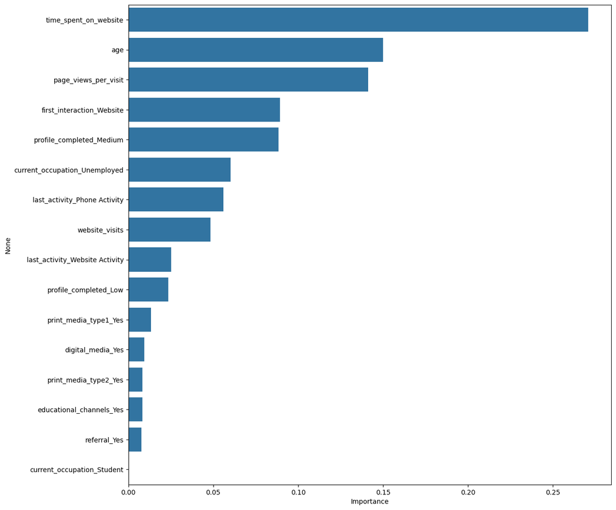

```python
importances = dt.feature_importances_
columns = df_X.columns
importance_df = pd.DataFrame(importances, index = columns, columns = ['Importance']).sort_values(by = 'Importance', ascending = False)
plt.figure(figsize = (13, 13))
sns.barplot(data = importance_df, x = importance_df.Importance, y = importance_df.index)
```

**Observations **

- According to decision tree, **time_spent_on_website** is the most important feature. The next important are **Age**, **page_views_per_visit**.
- This indicates that the leads **who spent more time on website browsing through the pages and little older in age are more likely to be converted to be the paid customer.**

## Do we need to prune the tree?

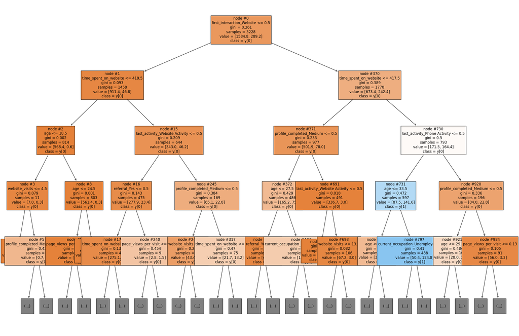

```python
# Lets plot a tree
features = list(df_X.columns)

plt.figure(figsize = (30, 20))

tree.plot_tree(dt, max_depth = 4, feature_names = features, filled = True, fontsize = 12, node_ids = True, class_names = True)

plt.show()
```

## Building a Random Forest model

```python
# Fitting the Random Forest classifier on the training data
rf_estimator = RandomForestClassifier(class_weight = {0: 70, 1: 0.30}, random_state = 1)

rf_estimator.fit(X_train, y_train)
```

```
RandomForestClassifier(class_weight={0: 70, 1: 0.3}, random_state=1)
```

```
              precision    recall  f1-score   support

           0       1.00      1.00      1.00      2264
           1       1.00      1.00      1.00       964

    accuracy                           1.00      3228
   macro avg       1.00      1.00      1.00      3228
weighted avg       1.00      1.00      1.00      3228
```

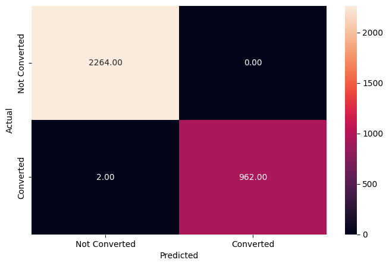

```python
# Checking performance on the training data
y_pred_train_rf = rf_estimator.predict(X_train)

metrics_score(y_train, y_pred_train_rf)
```

**Observation**

- Random Forest gives ~100% score.

```
              precision    recall  f1-score   support

           0       0.89      0.90      0.90       971
           1       0.76      0.74      0.75       413

    accuracy                           0.85      1384
   macro avg       0.82      0.82      0.82      1384
weighted avg       0.85      0.85      0.85      1384
```

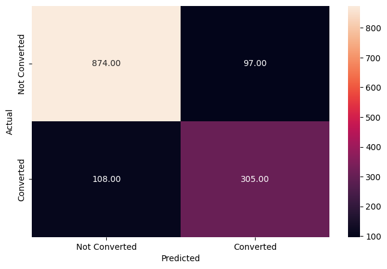

```python
# Checking performance on the testing data
y_pred_test_rf = rf_estimator.predict(X_test)

metrics_score(y_test, y_pred_test_rf)
```

** Observations **

- The Random Forest classifier **seems to be overfitting the training data**. The recall on the training data is 1, while the recall on the test data is only ~ 0.74 for class 1. Precision is high for the test data as well.

## Do we need to prune the tree?

I dont think we need to prune the tree.

### **Lets check feature importance for random forest**

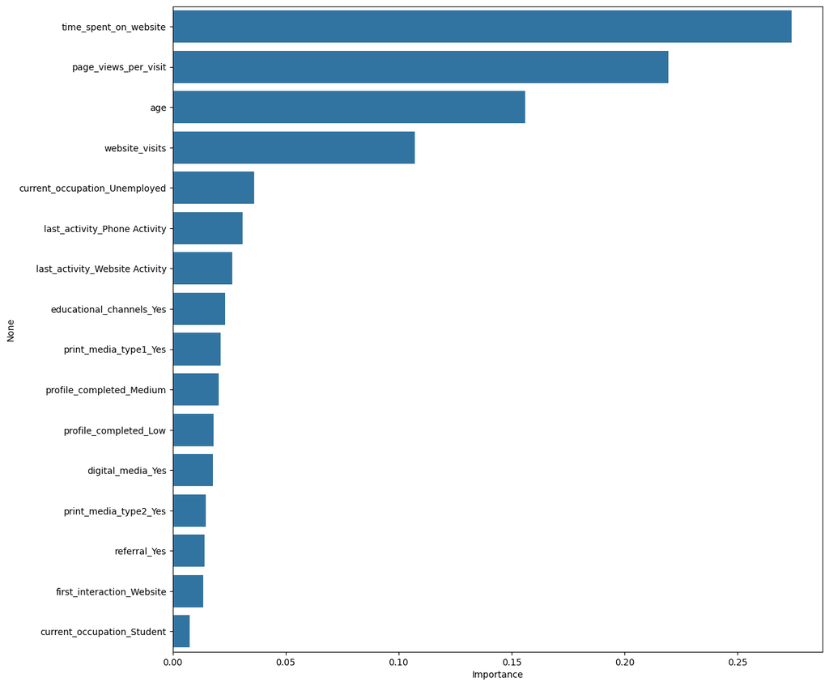

```python
#Lets check
importances = rf_estimator.feature_importances_
columns = df_X.columns
importance_df = pd.DataFrame(importances, index = columns, columns = ['Importance']).sort_values(by = 'Importance', ascending = False)
plt.figure(figsize = (13, 13))
sns.barplot(data = importance_df, x = importance_df.Importance, y = importance_df.index)
```

**Observations **

- as per random forest, most important features are **time_spent_on_website**, **page_views_per_visits**, **age** and **website_visits**
- It indicates that the leads spending more time on website and older in age are more likely to be converted to paid customer.
- Current occupation, last activity etc fields do not play significant role in determining if lead will be converted to paid customer or not.
- It also indicates that the more work needs to be done with mobile app to keep lead engage.